# High School Seniors t Test

```r
library(mosaic)
library(tidyverse)
library(pander)
library(ggplot2)
library(car)
library(DT)
library(readr)
library(readxl)
library(stringr)
library(dplyr)
library(expss)

HSS <- read_csv("../../Data/HighSchoolSeniors.csv")
#Remember: select "Session, Set Working Directory, To Source File Location", and then play this R-chunk into your console to read the HSS data into R.
```

**Comments to Critiquers:**

What I’ve done:

1. A data table was added to this analysis allowing you to now look at the original and modified data.
2. A link to the U.S. Census at School survey was added under the *Data* section.
3. `split.table = Inf` was added to my t.test summary.
4. `Outdoor_Activities_Hours ~ Allergies, data=HSSAllergies` was added to my QQ plots.
5. Wording was added to the Independent $t$-test summary and QQ-plot graphs.
6. Language about the QQ plots showing the data to be heavy-winged was updated to right-skewed.
7. Titles on summary table was updated.
8. The summary under the boxplot had Min, Q1, Q3, and Max added onto to it.
9. Conclusion paragraph was updated.

Questions I have:

- Why is there so much space after my Conclusion?
- What does `include=` in my R chunks do?

# Who Is Outside More?

I am comparing those with allegeries and how much time they spend outside. The null hypothesis is that people with and without allergies spend an equal amount of time outdoors. However, I propose that this will be incorrect that children with allergies will spend less time outside than their non-runny nose, non-teary eyed, and clear headed counterparts. In other words, those without allergies will spend more time outside than those without.

$$H_0: \underbrace{\mu_1}_\text{Without Allergies} - \underbrace{\mu_2}_\text{With Allergies} = 0$$
$$H_a: \underbrace{\mu_1}_\text{Without Allergies} - \underbrace{\mu_2}_\text{With Allergies} > 0$$

## Understanding The Data

### Summary

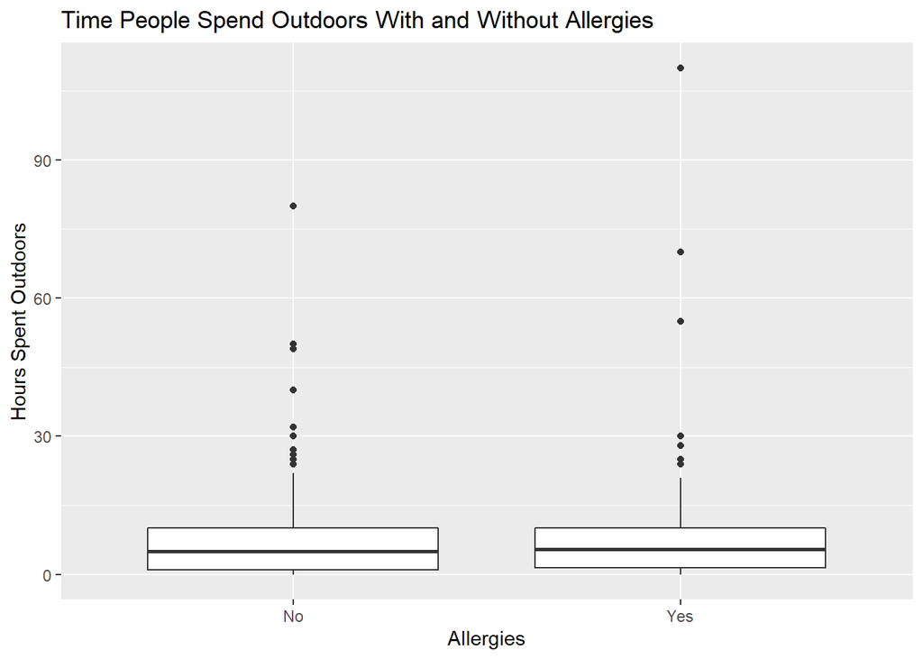

```r
HSSAllergies <- filter(HSS,
                       Allergies %in% c("Yes", "No")
                       & Outdoor_Activities_Hours <= 168)

#mPlot(HSSAllergies)

gf_boxplot(Outdoor_Activities_Hours ~ Allergies, data = HSSAllergies) %>% gf_labs(title = "Time People Spend Outdoors With and Without Allergies", x="Allergies", y="Hours Spent Outdoors")
```

```r
HSSAllergies <- filter(HSS,
                       Allergies %in% c("Yes", "No")
                       & Outdoor_Activities_Hours <= 168)
#HSSAllergies2 <- select(HSS, c(Allergies))
pander(HSSAllergies %>%
  group_by(Allergies) %>%
  summarise(`Avg. Outdoor Time` = mean(Outdoor_Activities_Hours,
                                    na.rm="TRUE"),
            Min = min(Outdoor_Activities_Hours, na.rm="TRUE"),
            Q1 = quantile(Outdoor_Activities_Hours, na.rm="TRUE", 0.25),
            `Median of Outdoor Time` = median(Outdoor_Activities_Hours,
                                  na.rm="TRUE"),
            Q3 = quantile(Outdoor_Activities_Hours, na.rm="TRUE", 0.75),
            max = max(Outdoor_Activities_Hours, na.rm="TRUE"),
            `Sample Size` = n( )),
  split.table = Inf,
  caption = "Summary of Boxplot")
```

Summary of Boxplot

| Allergies | Avg. Outdoor Time | Min | Q1 | Median of Outdoor Time | Q3 | max | Sample Size |
| --- | --- | --- | --- | --- | --- | --- | --- |
| No | 7.291 | 0 | 1 | 5 | 10 | 80 | 261 |
| Yes | 8.853 | 0 | 1.375 | 5.5 | 10 | 110 | 180 |

The average times reported by those with allergies surprisingly show that they spend more time outdoors, which is a curious observation. It leads me to wonder if their time outdoors has led to these cases of allergies. But, to determine this test’s accuracy and weight, I ran an independent sample t-test to pull the P-value of the data and QQ plots on those with and without allergies. The QQ plots were ran in order to test the data’s distribution and normality even though the sample size is large enough.

### My Test Results

```r
pander(t.test(Outdoor_Activities_Hours ~ Allergies,
              data=HSSAllergies,
              mu = 0,
              alternative = "greater",
              conf.level = 0.95),
       split.table = Inf,
       caption = "Independent Samples T-Test")
```

Independent Samples T-Test

| Test statistic | df | P value | Alternative hypothesis | mean in group No | mean in group Yes |
| --- | --- | --- | --- | --- | --- |
| -1.41 | 303.1 | 0.9202 | greater | 7.291 | 8.853 |

Test results from an Independent Samples $t$-Test show us that the average difference between time spent outside by those with and without allergies is of little importance, $p$-value = 0.9202. With this $p$-value, we are unable to reject our null hypothesis and thus determine that those with and without allergies actually spend about the same amount of time outside. Let’s see if this test is correct to use though.

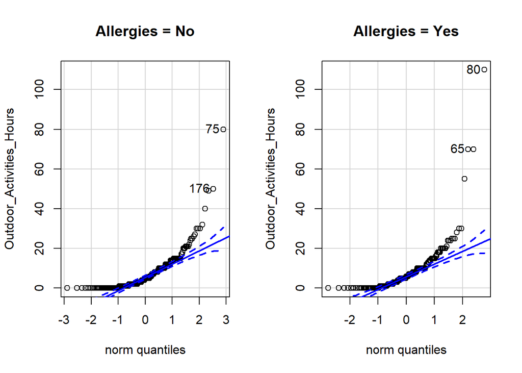

```r
qqPlot(Outdoor_Activities_Hours ~ Allergies,
       data=HSSAllergies)
```

```r
# How do I remove the table at the bottom of the qq-plot?
# It reads ## [1] 80 75

# Why is there so much space after my Conclusion?
```

Although the $p$-value gives us insufficent evidence to reject the null hypothesis, our Q-Q plots for both groups show us that the data is right-skewed. If we would like to continue using this data we need to understand that there is some abnormality within the data and cannot 100% relied upon the results. Additionally, the data of those with and without allergies is likely unrepresentative of the true population as this data was taken specifically from high school seniors. We will thus state the test to be incorrect to use. A Wilcoxon test is suggested to use for further analysis.

### Show Data

This data comes from a U.S. Census at School survey given to the High School senior students. A link to that survey can be found here:

- https://ww2.amstat.org/censusatschool/pdfs/C@SQuestionnaire.pdf

#### Modified Data

Before I started, I ran a boxplot to see if there were any outliers within the data. I found two points at 556 and 2000 hours per week. Since there are only 168 hours in one week, I have adjusted the data to accurately show data that is equal to or less than 168 hours per week.

```r
datatable(HSSAllergies, options=list(lengthMenu = c(15,50,100)), extensions = "Responsive")
```

|  | Country | Region | DataYear | ClassGrade | Gender | Ageyears | Handed | Height_cm | Footlength_cm | Armspan_cm | Languages_spoken | Travel_to_School | Travel_time_to_School | Reaction_time | Score_in_memory_game | Favourite_physical_activity | Importance_reducing_pollution | Importance_recycling_rubbish | Importance_conserving_water | Importance_saving_energy | Importance_owning_computer | Importance_Internet_access | Left_Footlength_cm | Longer_foot | Index_Fingerlength_mm | Ring_Fingerlength_mm | Longer_Finger_Lefthand | Birth_month | Favorite_Season | … |
| --- | --- | --- | --- | --- | --- | --- | --- | --- | --- | --- | --- | --- | --- | --- | --- | --- | --- | --- | --- | --- | --- | --- | --- | --- | --- | --- | --- | --- | --- | --- |
| 1 | USA | NY | 2018 | 12 | Female | 18 | Right-Handed | 166 | 21.9 |  | 2 | Rail (Train/Tram/Subway) | 40 | 0.368 | 61 | Gymnastics | 950 | 850 | 850 | 950 | 300 | 650 | 21.9 | Same length | 76 | 80 | Ring finger | November | Summer | … |
| 2 | USA | PA | 2018 | 12 | Male | 17 | Right-Handed | 189 | 28 | 185 | 1 | Car | 8 | 0.3 | 46 | Swimming | 960 | 936 | 892 | 949 | 674 | 977 | 28 | Same length | 100 | 95 | Index finger | April | Fall | … |
| 3 | USA | TN | 2018 | 12 | Female | 18 | Right-Handed | 164 | 23 | 164 | 1 | Car | 4 | 0.65 | 31 | None | 800 | 700 | 800 | 700 | 200 | 700 | 24 | Left foot | 70 | 75 | Ring finger | January | Summer | … |
| 4 | USA | IL | 2018 | 12 | Female | 17 | Right-Handed | 158 | 23 | 165 | 2 | Car | 4 | 0.315 | 38 | Athletics | 1000 | 1000 | 1000 | 1000 | 235 | 471 | 22 | Right foot | 88 | 103 | Ring finger | April | Fall | … |
| 5 | USA | CA | 2018 | 12 | Male | 17 | Right-Handed | 183 | 24 | 180 | 2 | Car | 10 | 0.373 | 46 | Baseball/Softball | 471 | 551 | 583 | 444 | 695 | 850 | 24 | Same length | 85 | 80 | Same length | March | Spring | … |
| 6 | USA | CA | 2018 | 12 | Male | 17 | Right-Handed | 156 | 23 | 160 | 2 | Car | 10 | 0.365 | 41 | Soccer | 500 | 250 | 500 | 250 | 250 | 750 | 24 | Left foot | 90 | 80 | Index finger | December | Winter | … |
| 7 | USA | CA | 2018 | 12 | Female | 17 | Right-Handed | 157 | 22 | 153 | 2 | Car | 12 | 0.148 | 29 | Dancing | 471 | 500 | 1000 | 500 | 1000 | 1000 | 23 | Left foot | 115 | 113 | Index finger | November | Winter | … |
| 8 | USA | IL | 2018 | 12 | Male | 18 | Left-Handed | 188 | 30 | 188 | 1 | Bus | 15 | 0.397 | 54 | Golf | 0 | 0 | 0 | 0 | 0 | 0 | 30 | Left foot | 150 | 140 | Ring finger | August | Winter | … |
| 9 | USA | ID | 2018 | 12 | Female | 23 | Right-Handed | 172 | 23 | 173 | 1 | Walk | 15 | 0.562 | 48 | Walking/Hiking | 800 | 800 | 800 | 800 | 700 | 800 | 24 | Left foot | 90 | 80 | Index finger | January | Fall | … |
| 10 | USA | MI | 2018 | 12 | Male | 18 | Right-Handed | 186 | 25 | 153 | 1 | Car | 9 | 0.4 | 79 | Football (American) | 1000 | 1000 | 658 | 754 | 406 | 1000 | 25 | Same length | 95 | 75 | Index finger | August | Summer | … |

[output cut: 431 more lines]

#### Original Data

```r
datatable(HSS, options=list(lengthMenu = c(15,50,100)), extensions = "Responsive")
```

|  | Country | Region | DataYear | ClassGrade | Gender | Ageyears | Handed | Height_cm | Footlength_cm | Armspan_cm | Languages_spoken | Travel_to_School | Travel_time_to_School | Reaction_time | Score_in_memory_game | Favourite_physical_activity | Importance_reducing_pollution | Importance_recycling_rubbish | Importance_conserving_water | Importance_saving_energy | Importance_owning_computer | Importance_Internet_access | Left_Footlength_cm | Longer_foot | Index_Fingerlength_mm | Ring_Fingerlength_mm | Longer_Finger_Lefthand | Birth_month | Favorite_Season | … |
| --- | --- | --- | --- | --- | --- | --- | --- | --- | --- | --- | --- | --- | --- | --- | --- | --- | --- | --- | --- | --- | --- | --- | --- | --- | --- | --- | --- | --- | --- | --- |
| 1 | USA | NY | 2018 | 12 | Female | 18 | Right-Handed | 166 | 21.9 |  | 2 | Rail (Train/Tram/Subway) | 40 | 0.368 | 61 | Gymnastics | 950 | 850 | 850 | 950 | 300 | 650 | 21.9 | Same length | 76 | 80 | Ring finger | November | Summer | … |
| 2 | USA | PA | 2018 | 12 | Male | 17 | Right-Handed | 189 | 28 | 185 | 1 | Car | 8 | 0.3 | 46 | Swimming | 960 | 936 | 892 | 949 | 674 | 977 | 28 | Same length | 100 | 95 | Index finger | April | Fall | … |
| 3 | USA | TN | 2018 | 12 | Female | 18 | Right-Handed | 164 | 23 | 164 | 1 | Car | 4 | 0.65 | 31 | None | 800 | 700 | 800 | 700 | 200 | 700 | 24 | Left foot | 70 | 75 | Ring finger | January | Summer | … |
| 4 | USA | IL | 2018 | 12 | Female | 17 | Right-Handed | 158 | 23 | 165 | 2 | Car | 4 | 0.315 | 38 | Athletics | 1000 | 1000 | 1000 | 1000 | 235 | 471 | 22 | Right foot | 88 | 103 | Ring finger | April | Fall | … |
| 5 | USA | CA | 2018 | 12 | Male | 17 | Right-Handed | 183 | 24 | 180 | 2 | Car | 10 | 0.373 | 46 | Baseball/Softball | 471 | 551 | 583 | 444 | 695 | 850 | 24 | Same length | 85 | 80 | Same length | March | Spring | … |
| 6 | USA | CA | 2018 | 12 | Male | 17 | Right-Handed | 156 | 23 | 160 | 2 | Car | 10 | 0.365 | 41 | Soccer | 500 | 250 | 500 | 250 | 250 | 750 | 24 | Left foot | 90 | 80 | Index finger | December | Winter | … |
| 7 | USA | CA | 2018 | 12 | Female | 17 | Right-Handed | 157 | 22 | 153 | 2 | Car | 12 | 0.148 | 29 | Dancing | 471 | 500 | 1000 | 500 | 1000 | 1000 | 23 | Left foot | 115 | 113 | Index finger | November | Winter | … |
| 8 | USA | IL | 2018 | 12 | Male | 18 | Left-Handed | 188 | 30 | 188 | 1 | Bus | 15 | 0.397 | 54 | Golf | 0 | 0 | 0 | 0 | 0 | 0 | 30 | Left foot | 150 | 140 | Ring finger | August | Winter | … |
| 9 | USA | ID | 2018 | 12 | Female | 23 | Right-Handed | 172 | 23 | 173 | 1 | Walk | 15 | 0.562 | 48 | Walking/Hiking | 800 | 800 | 800 | 800 | 700 | 800 | 24 | Left foot | 90 | 80 | Index finger | January | Fall | … |
| 10 | USA | MI | 2018 | 12 | Male | 18 | Right-Handed | 186 | 25 | 153 | 1 | Car | 9 | 0.4 | 79 | Football (American) | 1000 | 1000 | 658 | 754 | 406 | 1000 | 25 | Same length | 95 | 75 | Index finger | August | Summer | … |

[output cut: 490 more lines]

## Conclusion

Through an independent samples t-test, I found the $p$-value to be 0.92. Based upon the p-value, it turns out that there is insufficent evidence to reject the null hypothesis, thus showing that those with and without allergies do spend an equal amount of time outside. This stated, the results of our test cannot in good faith be relied upon because the data was taken from a very specific population and both QQ plots show that the data is right-skewed. An interesting follow-up study would be to first gather represenattive data and then find out if spending time outside is a factor in those who have allergies.